# Harsh Singal, OBAIS, University of Cincinnati (September 19, 2020)

# Lab-5

The objective of this case is to get you understand Decision Tree regression and classification and some important ideas such as asymmetric cost, ROC curve, tree pruning.

```python
import pandas as pd
import numpy as np
from sklearn import datasets
import matplotlib.pyplot as plt
import seaborn as sns
import warnings
warnings.filterwarnings("ignore")
```

In this lab we will go through the model building, validation, and interpretation of tree models.

# 1 Regression Tree vs. Classification Tree

CART stands for classification and regression tree.

- Regression tree: response variable Y is numerical
- Classification tree: response variable Y is categorical

For the regression tree example, we will use the Boston Housing data. Recall the response variable is the housing price. For the classification tree example, we will use the credit scoring data. The response variable is whether the loan went to default.

Note that unlkie logistic regreesion, the response variable does not have to be binary in case of classification tree. We can use classification tree on classification problems with more than 2 outcomes.

## 1.1 Regression Tree (Boston Housing Data)

Let us load the data sets. Random sampled training and test datasets will lead to different results,

```python
data = datasets.load_boston()
boston = pd.DataFrame(data.data, columns = map(str.lower, data.feature_names))
boston['medv'] = data.target
boston.head()
```

|  | crim | zn | indus | chas | nox | rm | age | dis | rad | tax | ptratio | b | lstat | medv |
| --- | --- | --- | --- | --- | --- | --- | --- | --- | --- | --- | --- | --- | --- | --- |
| 0 | 0.00632 | 18.0 | 2.31 | 0.0 | 0.538 | 6.575 | 65.2 | 4.0900 | 1.0 | 296.0 | 15.3 | 396.90 | 4.98 | 24.0 |
| 1 | 0.02731 | 0.0 | 7.07 | 0.0 | 0.469 | 6.421 | 78.9 | 4.9671 | 2.0 | 242.0 | 17.8 | 396.90 | 9.14 | 21.6 |
| 2 | 0.02729 | 0.0 | 7.07 | 0.0 | 0.469 | 7.185 | 61.1 | 4.9671 | 2.0 | 242.0 | 17.8 | 392.83 | 4.03 | 34.7 |
| 3 | 0.03237 | 0.0 | 2.18 | 0.0 | 0.458 | 6.998 | 45.8 | 6.0622 | 3.0 | 222.0 | 18.7 | 394.63 | 2.94 | 33.4 |
| 4 | 0.06905 | 0.0 | 2.18 | 0.0 | 0.458 | 7.147 | 54.2 | 6.0622 | 3.0 | 222.0 | 18.7 | 396.90 | 5.33 | 36.2 |

```python
from sklearn.model_selection import train_test_split

# Creating train and test set
X = boston.iloc[:,:-1]
Y = boston.iloc[:,-1:]

X_train, X_test, y_train, y_test = train_test_split(X, Y, test_size = 0.1, random_state = 0)
```

### 1.1.1 Printing and ploting the tree

```python
from sklearn.tree import DecisionTreeRegressor
from sklearn.tree import plot_tree
from sklearn import tree
clf = DecisionTreeRegressor(max_depth = 3, random_state = 0)
clf.fit(X_train, y_train)
text_representation = tree.export_text(clf, feature_names = list(X_train.columns.values))
print(text_representation)
```

```
|--- rm <= 6.94
|   |--- lstat <= 14.40
|   |   |--- lstat <= 4.91
|   |   |   |--- value: [31.56]
|   |   |--- lstat >  4.91
|   |   |   |--- value: [22.53]
|   |--- lstat >  14.40
|   |   |--- nox <= 0.61
|   |   |   |--- value: [18.30]
|   |   |--- nox >  0.61
|   |   |   |--- value: [12.86]
|--- rm >  6.94
|   |--- rm <= 7.44
|   |   |--- nox <= 0.66
|   |   |   |--- value: [33.46]
|   |   |--- nox >  0.66
|   |   |   |--- value: [14.40]
|   |--- rm >  7.44
|   |   |--- crim <= 2.74
|   |   |   |--- value: [46.01]
|   |   |--- crim >  2.74
|   |   |   |--- value: [21.90]
```

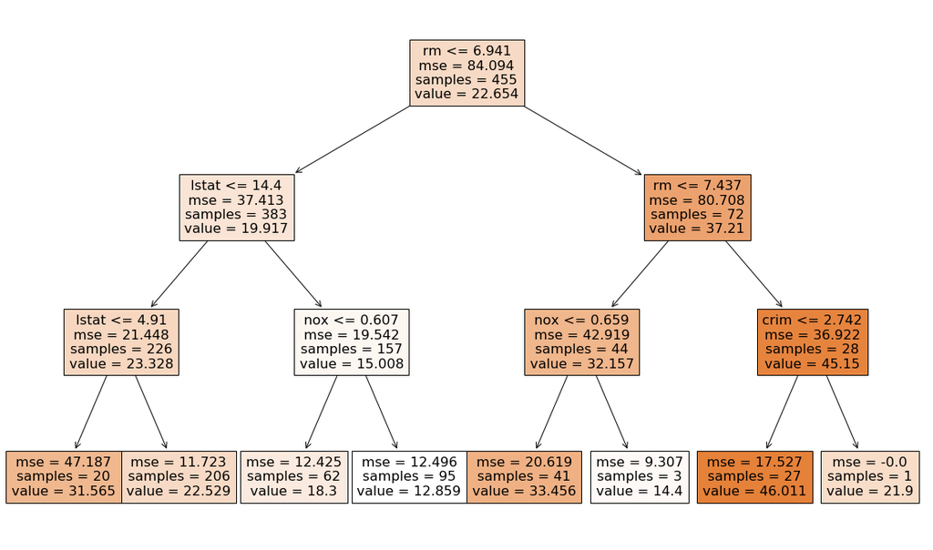

```python
fig = plt.figure(figsize=(20,12))
_ = tree.plot_tree(clf, feature_names = list(X_train.columns.values), filled=True)
```

Make sure you know how to interpret this tree model!

### 1.1.2 Prediction using regression tree

The in-sample and out-of-sample prediction for regression tree is also similar linear model prediction.

- In-sample prediction

```python
train_pred_tree = clf.predict(X_train)
```

- Out-of-sample prediction

```python
test_pred_tree = clf.predict(X_test)
```

We often denote MSE as training error, and MSPE as testing error when sample size is large.

```python
error = y_train['medv'] - train_pred_tree
MSE = (error*error).mean()
MSE
```

```
14.64308583830932
```

```python
test_error = y_test['medv'] - test_pred_tree
MSPE = (test_error*test_error).mean()
MSPE
```

```
43.22542849865316
```

## 1.2 Classification Tree (Credit Card Default data)

The classification tree is slightly more complicated to specify. What makes it more complicated is that we often have asymmetric cost function. In the credit scoring case it means that false negatives (predicting 0 when truth is 1, or giving out loans that end up in default) will cost more than false positives (predicting 1 when truth is 0, rejecting loans that you should not reject).

Here we make the assumption that false negative cost 10 times of false positive. In real life the cost structure should be carefully researched.

```python
credit_data = pd.read_csv("credit_default.csv")
credit_data.head()
```

|  | LIMIT_BAL | SEX | EDUCATION | MARRIAGE | AGE | PAY_0 | PAY_2 | PAY_3 | PAY_4 | PAY_5 | ... | BILL_AMT4 | BILL_AMT5 | BILL_AMT6 | PAY_AMT1 | PAY_AMT2 | PAY_AMT3 | PAY_AMT4 | PAY_AMT5 | PAY_AMT6 | default.payment.next.month |
| --- | --- | --- | --- | --- | --- | --- | --- | --- | --- | --- | --- | --- | --- | --- | --- | --- | --- | --- | --- | --- | --- |
| 0 | 290000 | 2 | 2 | 2 | 26 | 0 | 0 | 0 | 0 | -1 | ... | 100000 | 3015 | 23473 | 3000 | 80000 | 3000 | 3015 | 23473 | 1148 | 0 |
| 1 | 20000 | 1 | 2 | 2 | 51 | -1 | -1 | -2 | -1 | -1 | ... | 780 | 0 | 0 | 0 | 0 | 2280 | 0 | 0 | 0 | 0 |
| 2 | 280000 | 1 | 1 | 2 | 29 | -2 | -2 | -2 | -2 | -2 | ... | 2510 | 591 | 14994 | 5123 | 8467 | 2510 | 591 | 14994 | 5000 | 0 |
| 3 | 280000 | 2 | 1 | 2 | 47 | 0 | 0 | 0 | 0 | 0 | ... | 184270 | 130954 | 92215 | 11268 | 8196 | 6281 | 4403 | 3532 | 3510 | 0 |
| 4 | 20000 | 1 | 2 | 2 | 24 | 0 | 0 | 0 | 0 | 0 | ... | 19396 | 11643 | 11578 | 1400 | 1380 | 1181 | 1000 | 500 | 500 | 0 |

5 rows × 24 columns

```python
credit_data.dtypes
```

```
LIMIT_BAL                     int64
SEX                           int64
EDUCATION                     int64
MARRIAGE                      int64
AGE                           int64
PAY_0                         int64
PAY_2                         int64
PAY_3                         int64
PAY_4                         int64
PAY_5                         int64
PAY_6                         int64
BILL_AMT1                     int64
BILL_AMT2                     int64
BILL_AMT3                     int64
BILL_AMT4                     int64
BILL_AMT5                     int64
BILL_AMT6                     int64
PAY_AMT1                      int64
PAY_AMT2                      int64
PAY_AMT3                      int64
PAY_AMT4                      int64
PAY_AMT5                      int64
PAY_AMT6                      int64
default.payment.next.month    int64
dtype: object
```

```python
credit_data.rename(columns={'default.payment.next.month' : 'DEFAULT'}, inplace = True)
```

```python
credit_data.describe()
```

|  | LIMIT_BAL | SEX | EDUCATION | MARRIAGE | AGE | PAY_0 | PAY_2 | PAY_3 | PAY_4 | PAY_5 | ... | BILL_AMT4 | BILL_AMT5 | BILL_AMT6 | PAY_AMT1 | PAY_AMT2 | PAY_AMT3 | PAY_AMT4 | PAY_AMT5 | PAY_AMT6 | DEFAULT |
| --- | --- | --- | --- | --- | --- | --- | --- | --- | --- | --- | --- | --- | --- | --- | --- | --- | --- | --- | --- | --- | --- |
| count | 12000.000000 | 12000.000000 | 12000.000000 | 12000.000000 | 12000.000000 | 12000.000000 | 12000.000000 | 12000.000000 | 12000.000000 | 12000.000000 | ... | 12000.000000 | 12000.000000 | 12000.000000 | 12000.000000 | 1.200000e+04 | 12000.000000 | 12000.000000 | 12000.000000 | 12000.000000 | 12000.000000 |
| mean | 167501.333333 | 1.602917 | 1.844333 | 1.551500 | 35.499667 | -0.015750 | -0.128000 | -0.166667 | -0.225583 | -0.267833 | ... | 43101.557667 | 40314.199833 | 38821.438833 | 5766.057333 | 6.250060e+03 | 5194.665167 | 4878.389417 | 4868.498167 | 5432.712083 | 0.219333 |
| std | 130334.212375 | 0.489314 | 0.745306 | 0.520772 | 9.226480 | 1.128616 | 1.192645 | 1.187226 | 1.152522 | 1.123478 | ... | 64429.407522 | 61042.768474 | 59611.508898 | 15989.660757 | 2.362472e+04 | 17820.014810 | 15569.863239 | 15279.952500 | 19044.129946 | 0.413812 |
| min | 10000.000000 | 1.000000 | 1.000000 | 1.000000 | 21.000000 | -2.000000 | -2.000000 | -2.000000 | -2.000000 | -2.000000 | ... | -81334.000000 | -81334.000000 | -339603.000000 | 0.000000 | 0.000000e+00 | 0.000000 | 0.000000 | 0.000000 | 0.000000 | 0.000000 |
| 25% | 50000.000000 | 1.000000 | 1.000000 | 1.000000 | 28.000000 | -1.000000 | -1.000000 | -1.000000 | -1.000000 | -1.000000 | ... | 2411.000000 | 1863.250000 | 1308.750000 | 1000.000000 | 9.447500e+02 | 400.000000 | 300.000000 | 300.000000 | 142.750000 | 0.000000 |
| 50% | 140000.000000 | 2.000000 | 2.000000 | 2.000000 | 34.000000 | 0.000000 | 0.000000 | 0.000000 | 0.000000 | 0.000000 | ... | 19077.500000 | 18244.000000 | 17130.000000 | 2128.000000 | 2.013000e+03 | 1827.000000 | 1500.000000 | 1518.000000 | 1500.000000 | 0.000000 |
| 75% | 240000.000000 | 2.000000 | 2.000000 | 2.000000 | 41.000000 | 0.000000 | 0.000000 | 0.000000 | 0.000000 | 0.000000 | ... | 53117.250000 | 49927.250000 | 48938.000000 | 5006.000000 | 5.000000e+03 | 4505.000000 | 4078.500000 | 4120.750000 | 4061.750000 | 0.000000 |
| max | 1000000.000000 | 2.000000 | 4.000000 | 3.000000 | 79.000000 | 8.000000 | 7.000000 | 7.000000 | 7.000000 | 7.000000 | ... | 891586.000000 | 927171.000000 | 961664.000000 | 493358.000000 | 1.227082e+06 | 896040.000000 | 432130.000000 | 426529.000000 | 528666.000000 | 1.000000 |

8 rows × 24 columns

As you can see from the above description, columns named as Sex, Education and Marriage are categorical variables. Therefore we have to do some data manipulation so that data can be used to develop tree based model.

```python
#converting Sex data into binary format
credit_data.SEX = credit_data.SEX - 1

#converting Marriage and Education into one-hot format
credit_data = pd.get_dummies(credit_data, columns = ['MARRIAGE', 'EDUCATION'])
```

```python
credit_data.describe()
```

|  | LIMIT_BAL | SEX | AGE | PAY_0 | PAY_2 | PAY_3 | PAY_4 | PAY_5 | PAY_6 | BILL_AMT1 | ... | PAY_AMT5 | PAY_AMT6 | DEFAULT | MARRIAGE_1 | MARRIAGE_2 | MARRIAGE_3 | EDUCATION_1 | EDUCATION_2 | EDUCATION_3 | EDUCATION_4 |
| --- | --- | --- | --- | --- | --- | --- | --- | --- | --- | --- | --- | --- | --- | --- | --- | --- | --- | --- | --- | --- | --- |
| count | 12000.000000 | 12000.000000 | 12000.000000 | 12000.000000 | 12000.000000 | 12000.000000 | 12000.000000 | 12000.000000 | 12000.000000 | 12000.000000 | ... | 12000.000000 | 12000.000000 | 12000.000000 | 12000.000000 | 12000.000000 | 12000.000000 | 12000.000000 | 12000.000000 | 12000.000000 | 12000.000000 |
| mean | 167501.333333 | 0.602917 | 35.499667 | -0.015750 | -0.128000 | -0.166667 | -0.225583 | -0.267833 | -0.293083 | 51391.963833 | ... | 4868.498167 | 5432.712083 | 0.219333 | 0.460417 | 0.527667 | 0.011917 | 0.352333 | 0.466333 | 0.166000 | 0.015333 |
| std | 130334.212375 | 0.489314 | 9.226480 | 1.128616 | 1.192645 | 1.187226 | 1.152522 | 1.123478 | 1.136424 | 73970.169791 | ... | 15279.952500 | 19044.129946 | 0.413812 | 0.498451 | 0.499255 | 0.108516 | 0.477717 | 0.498886 | 0.372096 | 0.122880 |
| min | 10000.000000 | 0.000000 | 21.000000 | -2.000000 | -2.000000 | -2.000000 | -2.000000 | -2.000000 | -2.000000 | -15308.000000 | ... | 0.000000 | 0.000000 | 0.000000 | 0.000000 | 0.000000 | 0.000000 | 0.000000 | 0.000000 | 0.000000 | 0.000000 |
| 25% | 50000.000000 | 0.000000 | 28.000000 | -1.000000 | -1.000000 | -1.000000 | -1.000000 | -1.000000 | -1.000000 | 3690.500000 | ... | 300.000000 | 142.750000 | 0.000000 | 0.000000 | 0.000000 | 0.000000 | 0.000000 | 0.000000 | 0.000000 | 0.000000 |
| 50% | 140000.000000 | 1.000000 | 34.000000 | 0.000000 | 0.000000 | 0.000000 | 0.000000 | 0.000000 | 0.000000 | 22657.500000 | ... | 1518.000000 | 1500.000000 | 0.000000 | 0.000000 | 1.000000 | 0.000000 | 0.000000 | 0.000000 | 0.000000 | 0.000000 |
| 75% | 240000.000000 | 1.000000 | 41.000000 | 0.000000 | 0.000000 | 0.000000 | 0.000000 | 0.000000 | 0.000000 | 67207.250000 | ... | 4120.750000 | 4061.750000 | 0.000000 | 1.000000 | 1.000000 | 0.000000 | 1.000000 | 1.000000 | 0.000000 | 0.000000 |
| max | 1000000.000000 | 1.000000 | 79.000000 | 8.000000 | 7.000000 | 7.000000 | 7.000000 | 7.000000 | 8.000000 | 964511.000000 | ... | 426529.000000 | 528666.000000 | 1.000000 | 1.000000 | 1.000000 | 1.000000 | 1.000000 | 1.000000 | 1.000000 | 1.000000 |

8 rows × 29 columns

```python
# Creating train and test set
X = credit_data.iloc[:, credit_data.columns != 'DEFAULT']
Y = credit_data['DEFAULT']

X_train, X_test, y_train, y_test = train_test_split(X, Y, test_size = 0.2, random_state = 0)
```

```python
from sklearn.tree import DecisionTreeClassifier

clf = DecisionTreeClassifier(max_depth = 3, random_state = 0)
clf.fit(X_train, y_train)
```

```
DecisionTreeClassifier(max_depth=3, random_state=0)
```

For tree models with symmetric cost, we can directly use predict function to get the predicted values and misclassification rate. Below is a look at the confusion matrix from the developed model.

```python
y_train_pred = clf.predict(X_train)

data_pred_tree = pd.DataFrame({'Predicted': y_train_pred, 'True': y_train})
confusion_matrix = pd.crosstab(data_pred_tree['True'], data_pred_tree['Predicted'], rownames=['True'], colnames=['Predicted'])
print('Confusion_matrix for train data on Decision Tree Model is\n')
print(confusion_matrix)
```

```
Confusion_matrix for train data on Decision Tree Model is

Predicted     0    1
True
0          7139  382
1          1283  796
```

For most applications (very unbalanced data), we often use asymmetric cost. Recall the example in logistic regression. In the credit scoring case it means that false negatives (predicting 0 when truth is 1, or giving out loans that end up in default) will cost more than false positives (predicting 1 when truth is 0, rejecting loans that you should not reject).

Here we can make the assumption that false negative cost 10 times of false positive and can find optimal threshold value for the model. In real life the cost structure should be carefully researched.

### 1.2.1 Printing and ploting the tree

```python
text_representation = tree.export_text(clf, feature_names = list(X_train.columns.values))
print(text_representation)
```

```
|--- PAY_0 <= 1.50
|   |--- PAY_2 <= 1.50
|   |   |--- PAY_AMT3 <= 634.50
|   |   |   |--- class: 0
|   |   |--- PAY_AMT3 >  634.50
|   |   |   |--- class: 0
|   |--- PAY_2 >  1.50
|   |   |--- PAY_5 <= 1.00
|   |   |   |--- class: 0
|   |   |--- PAY_5 >  1.00
|   |   |   |--- class: 1
|--- PAY_0 >  1.50
|   |--- PAY_3 <= -0.50
|   |   |--- BILL_AMT5 <= 195.00
|   |   |   |--- class: 1
|   |   |--- BILL_AMT5 >  195.00
|   |   |   |--- class: 0
|   |--- PAY_3 >  -0.50
|   |   |--- PAY_6 <= 1.00
|   |   |   |--- class: 1
|   |   |--- PAY_6 >  1.00
|   |   |   |--- class: 1
```

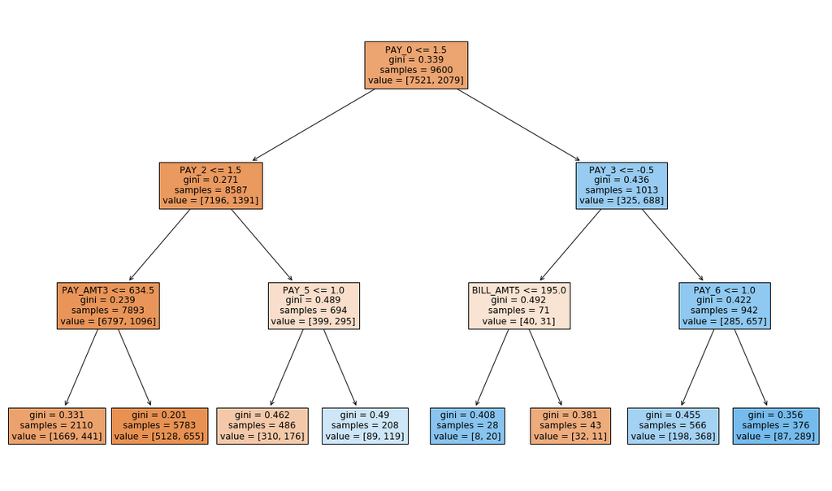

```python
fig = plt.figure(figsize=(20,12))
_ = tree.plot_tree(clf, feature_names = list(X_train.columns.values), filled=True)
```

### 1.2.2 Prediction (Asymmetric cost) using classification tree

For a binary classification problem, as you learned in logistic regression there are 2 types of predictions. One is the predicted class of response (0 or 1), and the second type is the probability of response being 1. We use an argument "predict_prob" to get these:

#### In-sample prediction (asymmetric cost function)

Here we have used threshold value fpr probability to be 0.2 which can be seen as that weight of 5 has been given to False Negative values.

```python
y_train_prob = clf.predict_proba(X_train)[:,1]

y_train_assy = (y_train_prob > 0.2)*1

data_pred_assy = pd.DataFrame({'Predicted': y_train_assy, 'True': y_train})
confusion_matrix = pd.crosstab(data_pred_assy['True'], data_pred_assy['Predicted'], rownames=['True'], colnames=['Predicted'])
print('Confusion_matrix for train data on Decision Tree Model is\n')
print(confusion_matrix)
```

```
Confusion_matrix for train data on Decision Tree Model is

Predicted     0     1
True
0          5128  2393
1           655  1424
```

**Exercise**: Out-of-sample prediction

Usually if you want a hassle-free model, using "predict_proba" is enough given that you specified the threshold value correctly in finding predicted values.

We can get the expected loss for this tree model by defining a cost function that has the correct weights.

### 1.2.3 Calculate the actual cost using a self-defined cost function

We can get the expected loss for this tree model by defining a cost function that has the correct weights:

```python
y_train_prob = clf.predict_proba(X_train)[:,1]

def costfunc(obs, pred, threshold):
    weight1 = 10
    weight0 = 1
    c1 = (obs==1) & (pred < threshold)
    c0 = (obs==0) & (pred >= threshold)
    cost = (weight1*c1 + weight0*c0).mean()
    return cost

costfunc(obs = y_train, pred = y_train_prob, threshold = seq[i])
```

[output not shown]

**Exercise:** Calculate the cost for testing sample.

### 1.2.4 Comparing this classification tree with logistic regression

We can compare this model’s out-of-sample performance with the logistic regression model with all variables in it. Recall that when we search for the optimal cut-off using the same cost function we get optimal cut-off at about 0.24.

**Exercise:** Comparison for in-sample performance.

Which model do you think is better?

### 1.2.5 ROC Curve and Cut-off Probability for Classification Tree

Recall that ROC Curve gives you the trade-off between hit rate (1 - false positive) and false negative, and area under the curve (AUC) can be used as a measure of how good the binary classification model performs when you do not know the cost function.

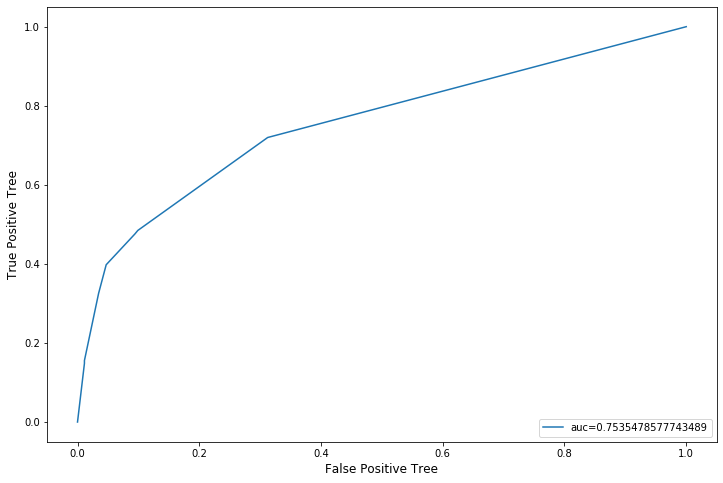

```python
import sklearn.metrics as metrics

y_test_prob = clf.predict_proba(X_test)[:,1]

fpr, tpr, _ = metrics.roc_curve(y_test,  y_test_prob)

auc = metrics.roc_auc_score(y_test, y_test_prob)

plt.figure(figsize=(12,8))
plt.plot(fpr,tpr,label="auc="+str(auc))
plt.legend(loc=4)
plt.xlabel('False Positive Tree', fontsize = 12)
plt.ylabel('True Positive Tree', fontsize = 12)
plt.show()
```

Area under the curve is given by -

```python
metrics.roc_auc_score(y_test, y_test_prob)
```

```
0.7535478577743489
```

For a given cut-off probability, the 0/1 prediction result can be calculated similar to what you do in logistic regression

```python
y_test_assy = (y_test_prob > (1/5))*1

data_pred_assy = pd.DataFrame({'Predicted': y_test_assy, 'True': y_test})
confusion_matrix = pd.crosstab(data_pred_assy['True'], data_pred_assy['Predicted'], rownames=['True'], colnames=['Predicted'])
print('Confusion_matrix for test data on Decision Tree Model for asymmetric cost is\n')
print(confusion_matrix)
```

```
Confusion_matrix for test data on Decision Tree Model for asymmetric cost is

Predicted     0    1
True
0          1270  577
1           155  398
```

If you know the cost structure of mis-classification, there is usually no need to search for an optimal cut-off probability as we did in the logistic regression.

**Exercise:** Draw the ROC curve for training sample

### 1.3 Pruning

Here we will use cost complexity pruning. Minimal cost complexity pruning recursively finds the node with the “weakest link”. The weakest link is characterized by an effective alpha, where the nodes with the smallest effective alpha are pruned first. To get an idea of what values of ccp_alpha could be appropriate, scikit-learn provides DecisionTreeClassifier.cost_complexity_pruning_path that returns the effective alphas and the corresponding total leaf impurities at each step of the pruning process. As alpha increases, more of the tree is pruned, which increases the total impurity of its leaves.

Refer to https://scikit-learn.org/stable/auto_examples/tree/plot_cost_complexity_pruning.html for more information

In DecisionTree, the ccp_alpha argument is one of the parameters that are used to control the compexity of the tree. It ensures that any split that does not decrease the overall lack of fit by a factor of ccp_aplha is not attempted. For a regression tree, the overall R-square must increase by ccp_aplha at each step. Basically, the smaller the ccp_aplha value, the larger (complex) tree rpart will attempt to fit.

```python
path = clf.cost_complexity_pruning_path(X_train, y_train)
ccp_alphas, impurities = path.ccp_alphas, path.impurities
```

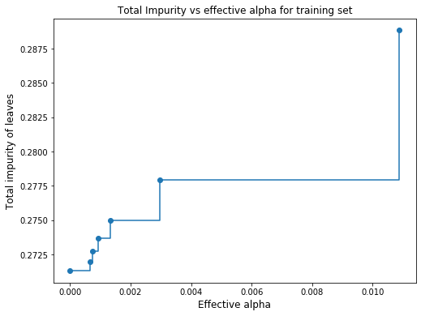

```python
plt.figure(figsize=(8,6))
plt.plot(ccp_alphas[:-1], impurities[:-1], marker='o', drawstyle="steps-post")
plt.xlabel("Effective alpha", fontsize = 12)
plt.ylabel("Total impurity of leaves", fontsize = 12)
plt.title("Total Impurity vs effective alpha for training set", fontsize = 12)
plt.show()
```

Above graph shows that as alpha increases, tree size decreases and total impurity of leaves increases

```python
DTs = []
for ccp_alpha in ccp_alphas:
    DT = DecisionTreeClassifier(random_state=0, ccp_alpha=ccp_alpha)
    DT.fit(X_train, y_train)
    DTs.append(DT)
print("Number of nodes in the last tree is {} with ccp_alpha: {}".format(
      DTs[-1].tree_.node_count, ccp_alphas[-1]))
```

```
Number of nodes in the last tree is 1 with ccp_alpha: 0.050492256682065306
```

Below plot shows that as you increase alpha value, tree becomes shorter. Max alpha value that can be used is 0.0504922 as the tree will have only one node in that.

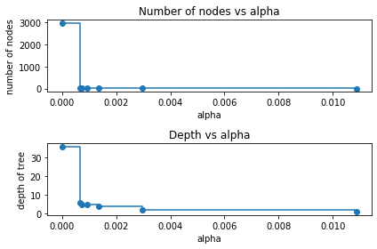

```python
DTs = DTs[:-1]
ccp_alphas = ccp_alphas[:-1]

node_counts = [DT.tree_.node_count for DT in DTs]
depth = [DT.tree_.max_depth for DT in DTs]
fig, ax = plt.subplots(2, 1)
ax[0].plot(ccp_alphas, node_counts, marker='o', drawstyle="steps-post")
ax[0].set_xlabel("alpha")
ax[0].set_ylabel("number of nodes")
ax[0].set_title("Number of nodes vs alpha")
ax[1].plot(ccp_alphas, depth, marker='o', drawstyle="steps-post")
ax[1].set_xlabel("alpha")
ax[1].set_ylabel("depth of tree")
ax[1].set_title("Depth vs alpha")
fig.tight_layout()
```

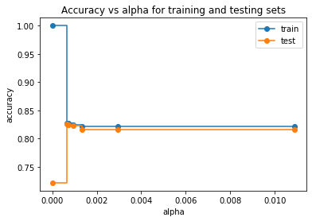

```python
train_scores = [DT.score(X_train, y_train) for DT in DTs]
test_scores = [DT.score(X_test, y_test) for DT in DTs]

fig, ax = plt.subplots()
ax.set_xlabel("alpha")
ax.set_ylabel("accuracy")
ax.set_title("Accuracy vs alpha for training and testing sets")
ax.plot(ccp_alphas, train_scores, marker='o', label="train",
        drawstyle="steps-post")
ax.plot(ccp_alphas, test_scores, marker='o', label="test",
        drawstyle="steps-post")
ax.legend()
plt.show()
```

A good choice of ccp_alpha for pruning is often the value for which the there is drop and increase in accuracy of training and test model respectively. Above graph shows that as alpha increases accuracy of training dataset decreases while testing dataset accuracy increases. Optimum value of alpha would be between 0.000 and 0.002.

```python
clf = DecisionTreeClassifier(ccp_alpha=0.001, min_samples_leaf=3)
clf.fit(X_train,y_train)
```

```
DecisionTreeClassifier(ccp_alpha=0.001, min_samples_leaf=3)
```

```python
y_train_pred = clf.predict(X_train)

data_pred_tree = pd.DataFrame({'Predicted': y_train_pred, 'True': y_train})
confusion_matrix = pd.crosstab(data_pred_tree['True'], data_pred_tree['Predicted'], rownames=['True'], colnames=['Predicted'])
print('Confusion_matrix for train data on Decision Tree Model is\n')
print(confusion_matrix)
```

```
Confusion_matrix for train data on Decision Tree Model is

Predicted     0    1
True
0          7107  414
1          1272  807
```